# Analisis Ejemplo

Alicia Perdices Guerra

6 de mayo, 2021

#### **1.GASTO SANITARIO POR FUNCIÓN.**

- En primer lugar leemos el fichero:

```r
library(scales)
gasto_fun<-read.csv("C:/temp/GastoSanitario_Funcion_clean.csv",sep= ",")
```

- Realicemos una breve inspección de los datos:

```r
str(gasto_fun)
```

```
## 'data.frame':    2000 obs. of  6 variables:
##  $ TIME     : int  2009 2009 2009 2009 2009 2009 2009 2009 2009 2009 ...
##  $ GEO      : Factor w/ 40 levels "Austria","Belgium",..: 15 15 15 15 15 16 16 16 16 16 ...
##  $ UNIT     : Factor w/ 1 level "Million euro": 1 1 1 1 1 1 1 1 1 1 ...
##  $ ICHA11_HC: Factor w/ 5 levels "Curative care",..: 3 2 1 4 5 3 2 1 4 5 ...
##  $ Value    : num  1213034 651215 15567 324207 8868 ...
##  $ Value_imp: logi  TRUE TRUE TRUE TRUE TRUE TRUE ...
```

```r
colnames(gasto_fun) #Nombre de las variables
```

```
## [1] "TIME"      "GEO"       "UNIT"      "ICHA11_HC" "Value"     "Value_imp"
```

```r
nrow(gasto_fun) #Número de registros
```

```
## [1] 2000
```

```r
ncol(gasto_fun) #Número de variables
```

```
## [1] 6
```

```r
gasto_fun_paises<-gasto_fun[(gasto_fun$GEO!="European Union - 27 countries (from 2020)")&
                              +(gasto_fun$GEO!="European Union - 27 countries (2007-2013)")&
                              +(gasto_fun$GEO!="Euro area - 19 countries  (from 2015)")&
                              +(gasto_fun$GEO!="Euro area - 12 countries (2001-2006)")&
                              +(gasto_fun$GEO!="European Union - 28 countries +(2013-2020)")&
                              +(gasto_fun$GEO!="European Union - 15 countries (1995-2004)")&
                              +(gasto_fun$GEO!="Euro area - 18 countries (2014)"),]
gasto_fun_paises<-gasto_fun_paises[(gasto_fun_paises$ICHA11_HC=="Current health care expenditure (CHE)"),]
```

- Transformamos el valor de la variable “Value” a unidades.

```r
#Ahora reescalamos un variable "Value" del Dataframe
gasto_fun_paises$Value<-gasto_fun_paises$Value*1000000
head(gasto_fun_paises)
```

```
##    TIME                                              GEO         UNIT
## 6  2009        European Union - 28 countries (2013-2020) Million euro
## 36 2009                                          Belgium Million euro
## 41 2009                                         Bulgaria Million euro
## 46 2009                                          Czechia Million euro
## 51 2009                                          Denmark Million euro
## 56 2009 Germany (until 1990 former territory of the FRG) Million euro
##                                ICHA11_HC        Value Value_imp
## 6  Current health care expenditure (CHE) 1.474601e+12      TRUE
## 36 Current health care expenditure (CHE) 3.587939e+10     FALSE
## 41 Current health care expenditure (CHE) 3.003510e+09      TRUE
## 46 Current health care expenditure (CHE) 1.220211e+10      TRUE
## 51 Current health care expenditure (CHE) 2.516702e+10      TRUE
## 56 Current health care expenditure (CHE) 2.748410e+11     FALSE
```

- Graficamos la información:

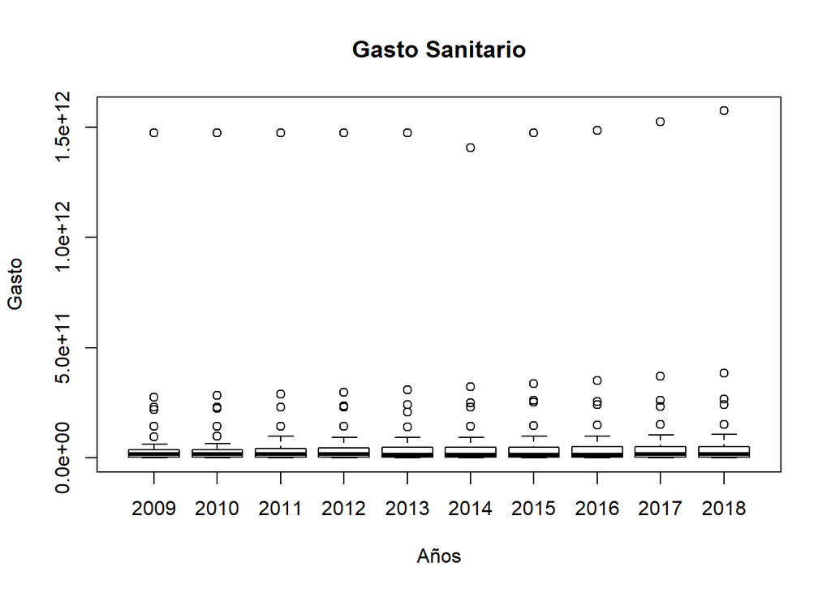

```r
boxplot(gasto_fun_paises$Value~gasto_fun_paises$TIME,xlab="Años",
        ylab="Gasto", main='Gasto Sanitario',)
```

#### **2.INGRESOS EN EL SECTOR SANITARIO.**

- En primer lugar leemos el fichero:

```r
ingreso<-read.csv("C:/temp/IngresosSanitarios_Financiacion_clean.csv",sep= ",")
```

- Realicemos una breve inspección de los datos:

```r
str(ingreso)
```

```
## 'data.frame':    220 obs. of  6 variables:
##  $ TIME     : int  2009 2009 2009 2009 2009 2009 2009 2009 2009 2009 ...
##  $ GEO      : Factor w/ 22 levels "Belgium","Croatia",..: 1 4 5 8 6 11 19 2 3 12 ...
##  $ UNIT     : Factor w/ 1 level "Million euro": 1 1 1 1 1 1 1 1 1 1 ...
##  $ ICHA11_FS: Factor w/ 1 level "All revenues of financing schemes": 1 1 1 1 1 1 1 1 1 1 ...
##  $ Value    : num  35879 35879 25167 274841 926 ...
##  $ Value_imp: logi  FALSE TRUE TRUE FALSE FALSE TRUE ...
```

```r
colnames(ingreso) #Nombre de las variables
```

```
## [1] "TIME"      "GEO"       "UNIT"      "ICHA11_FS" "Value"     "Value_imp"
```

```r
nrow(ingreso) #Número de registros
```

```
## [1] 220
```

```r
ncol(ingreso) #Número de variables
```

```
## [1] 6
```

- Transformamos el valor de la variable “Value” a unidades.

```r
#Ahora reescalamos un variable "Value" del Dataframe
ingreso$Value<-ingreso$Value*1000000
head(ingreso)
```

```
##   TIME                                              GEO         UNIT
## 1 2009                                          Belgium Million euro
## 2 2009                                          Czechia Million euro
## 3 2009                                          Denmark Million euro
## 4 2009 Germany (until 1990 former territory of the FRG) Million euro
## 5 2009                                          Estonia Million euro
## 6 2009                                          Ireland Million euro
##                           ICHA11_FS        Value Value_imp
## 1 All revenues of financing schemes  35879390000     FALSE
## 2 All revenues of financing schemes  35879390000      TRUE
## 3 All revenues of financing schemes  25167020000      TRUE
## 4 All revenues of financing schemes 274841000000     FALSE
## 5 All revenues of financing schemes    925550000     FALSE
## 6 All revenues of financing schemes  18850220000      TRUE
```

- Graficamos la información:

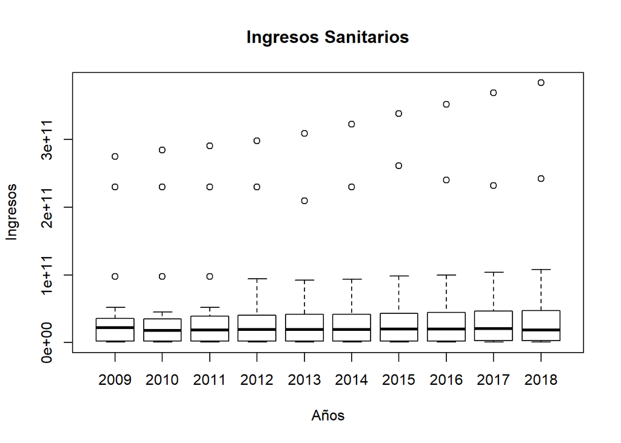

```r
boxplot(ingreso$Value~ingreso$TIME,xlab="Años", ylab="Ingresos", main='Ingresos Sanitarios',)
```

#### **3.ESTUDIO PARA ESPAÑA.**

##### **3.1 Creación de un DataFrame con la información para España.**

- Creamos un Dataframe con toda la información de España
- **Gasto Sanitario**

```r
spain_gasto_fun<-gasto_fun_paises[gasto_fun_paises$GEO=="Spain",]
gasto_fun_s<-spain_gasto_fun$Value
```

- **Ingresos Sanitarios**

```r
spain_ingreso<-ingreso[ingreso$GEO=="Spain",]
ingreso_s<-spain_ingreso$Value
```

- **Recursos: STAFF**

```r
#RECURSOS
#STAFF
medicos_e<-read.csv("C:/temp/Medicos_x_especialidad_clean.csv",sep= ",")
enfermeria<-read.csv("C:/temp/Personal_Enfermeria_Cuidados_clean.csv",sep= ",")


medicos_e<-medicos_e[(medicos_e$MED_SPEC=="Generalist medical practitioners"),]
medicos_e_s<-medicos_e[medicos_e$GEO=="Spain",]
medicos_sp<-medicos_e_s$Value


enfermeria<-enfermeria[(enfermeria$UNIT=="Number")&
  +(enfermeria$WSTATUS=="Professionally active")&
  +(enfermeria$ISCO08=="Nurses, midewives, health care assistants and home-based personal care workers"),]
enfermeria_s<-enfermeria[enfermeria$GEO =="Spain",]

enfermeria_sp<-enfermeria_s$Value
```

- **Prevención**

```r
cancer<-read.csv("C:/temp/Deteccion_Cancer_Mama_Cervix_clean.csv",sep= ",")
cancer_e<-cancer[cancer$SOURCE=="Survey data",]
cancer_e<-cancer_e[cancer_e$GEO=="Spain",]
cancer_e<-cancer_e[cancer_e$ICD10 == "Malignant neoplasm of breast",]
cancer_ep<-cancer_e$Value
cancer_ep
```

```
##  [1] 79.80 77.10 79.80 79.80 79.80 79.80 79.80 81.48 79.80 79.80
```

- **Causas de Muerte**

```r
#CAUSAS DE MUERTE
mortalidad<-read.csv("C:/temp/Mortalidad_Tratable_Prevenible_clean.csv",sep= ",")
mortalidad_e<-mortalidad[mortalidad$MORTALIT=="Total",]
mortalidad_e<-mortalidad_e[mortalidad_e$SEX=="Total",]
mortalidad_e<-mortalidad_e[mortalidad_e$UNIT=="Number",]
mortalidad_e<-mortalidad_e[mortalidad_e$GEO=="Spain",]
mortalidad_ep<-mortalidad_e$Value
mortalidad_ep<-c(mortalidad_ep,NA,NA,NA)
mortalidad_ep
```

```
##  [1] 75150 74282 73920 73685 74653 74599 74651    NA    NA    NA
```

- Creamos un DataFrame con la información para España.

```r
#Creamos el dataframe para España
year<-enfermeria_s$TIME
spain<-data.frame("year"=year,"gastos"=gasto_fun_s,
                  "ingresos"=ingreso_s,"medicos"=medicos_sp,
                  "enfermeros"=enfermeria_sp,
                  "diagnostico_cancer_mama"=cancer_ep,
                  "mortalidad"=mortalidad_ep)
spain
```

```
##    year       gastos     ingresos medicos enfermeros diagnostico_cancer_mama
## 1  2010  97384010000  97384010000   34620     206145                   79.80
## 2  2011  97815780000  97815780000   34722     218540                   77.10
## 3  2012  97532090000  97532090000   35061     232771                   79.80
## 4  2013  94417660000  94417660000   35017     245866                   79.80
## 5  2014  92518800000  92518800000   34880     250633                   79.80
## 6  2015  93824250000  93824250000   34735     256033                   79.80
## 7  2016  98350220000  98350220000   34797     266667                   79.80
## 8  2017  99715250000  99715250000   35378     277533                   81.48
## 9  2018 103899870000 103899870000   35798     284733                   79.80
## 10 2019 108109700000 108109700000   35378     168590                   79.80
##    mortalidad
## 1       75150
## 2       74282
## 3       73920
## 4       73685
## 5       74653
## 6       74599
## 7       74651
## 8          NA
## 9          NA
## 10         NA
```

- Imputamos los valores de la variable **mortalidad** para los años 2017-2019

```r
#Imputamos valores de la variable mortalidad en los años 2017-2019
idx<-which(is.na(spain$mortalidad))
length(idx)
```

```
## [1] 3
```

```r
library(VIM)
output<-kNN(spain, variable=c("mortalidad"),k=3)
spain<-output
```

- Normalizamos los valores del dataframe creado.

```r
spain_norm<-abs(scale(spain[,2:7]))
spain_norm
```

```
##           gastos   ingresos    medicos enfermeros diagnostico_cancer_mama
##  [1,] 0.20647994 0.20647994 1.11911071  0.9775872              0.09672527
##  [2,] 0.11483094 0.11483094 0.84641770  0.6274411              2.46364962
##  [3,] 0.17504797 0.17504797 0.05988552  0.2254297              0.09672527
##  [4,] 0.83612774 0.83612774 0.05774675  0.1444907              0.09672527
##  [5,] 1.23918639 1.23918639 0.42401089  0.2791537              0.09672527
##  [6,] 0.96208702 0.96208702 0.81166271  0.4316982              0.09672527
##  [7,] 0.00138884 0.00138884 0.64590814  0.7320979              0.09672527
##  [8,] 0.28835719 0.28835719 0.90737261  1.0390514              1.68984743
##  [9,] 1.17659922 1.17659922 2.03022617  1.2424441              0.09672527
## [10,] 2.07019242 2.07019242 0.90737261  2.0384779              0.09672527
##       mortalidad
##  [1,]  1.7220199
##  [2,]  0.1303946
##  [3,]  0.9029454
##  [4,]  1.4044631
##  [5,]  0.6613632
##  [6,]  0.5461208
##  [7,]  0.6570950
##  [8,]  0.9029454
##  [9,]  0.9029454
## [10,]  0.6570950
## attr(,"scaled:center")
##                  gastos                ingresos                 medicos
##            9.835676e+10            9.835676e+10            3.503860e+04
##              enfermeros diagnostico_cancer_mama              mortalidad
##            2.407511e+05            7.969800e+01            7.434310e+04
## attr(,"scaled:scale")
##                  gastos                ingresos                 medicos
##            4.711126e+09            4.711126e+09            3.740470e+02
##              enfermeros diagnostico_cancer_mama              mortalidad
##            3.539950e+04            1.054533e+00            4.685776e+02
```

```r
spain_norm<-cbind(spain_norm, year=c(year))
spain_norm<-data.frame(spain_norm)
```

##### **3.2 Aplicación de un modelo lineal que explique la variable mortalidad en función de gasto y número de staff en hospital.**

```r
modelo<-lm(mortalidad~medicos, data=spain) #modelo que explica la variable mortalidad
                                         #en función del número de médicos disponibles.
summary(modelo)
```

```
##
## Call:
## lm(formula = mortalidad ~ medicos, data = spain)
##
## Residuals:
##     Min      1Q  Median      3Q     Max
## -673.11 -257.68   74.82  184.73  543.83
##
## Coefficients:
##               Estimate Std. Error t value Pr(>|t|)
## (Intercept) 98699.7499 12910.9770   7.645 6.05e-05 ***
## medicos        -0.6951     0.3685  -1.887   0.0959 .
## ---
## Signif. codes:  0 '***' 0.001 '**' 0.01 '*' 0.05 '.' 0.1 ' ' 1
##
## Residual standard error: 413.5 on 8 degrees of freedom
## Multiple R-squared:  0.3079, Adjusted R-squared:  0.2214
## F-statistic: 3.559 on 1 and 8 DF,  p-value: 0.09593
```

```r
modelo2<-lm(mortalidad~gastos, data=spain) #modelo que explica la variable mortalidad
                                       #en función del gasto aplicado al sector sanitario.
summary(modelo2)
```

```
##
## Call:
## lm(formula = mortalidad ~ gastos, data = spain)
##
## Residuals:
##     Min      1Q  Median      3Q     Max
## -671.88 -414.69   88.53  303.28  803.50
##
## Coefficients:
##               Estimate Std. Error t value Pr(>|t|)
## (Intercept)  7.469e+04  3.460e+03   21.59 2.24e-08 ***
## gastos      -3.498e-09  3.514e-08   -0.10    0.923
## ---
## Signif. codes:  0 '***' 0.001 '**' 0.01 '*' 0.05 '.' 0.1 ' ' 1
##
## Residual standard error: 496.7 on 8 degrees of freedom
## Multiple R-squared:  0.001237,   Adjusted R-squared:  -0.1236
## F-statistic: 0.00991 on 1 and 8 DF,  p-value: 0.9232
```

```r
modelo3<-lm(mortalidad~enfermeros, data= spain)#modelo que explica la mortalidad
                                       #en función del número de enfermeros disponibles.
summary(modelo3)
```

```
##
## Call:
## lm(formula = mortalidad ~ enfermeros, data = spain)
##
## Residuals:
##    Min     1Q Median     3Q    Max
## -627.3 -199.8 -142.5  364.1  598.3
##
## Coefficients:
##               Estimate Std. Error t value Pr(>|t|)
## (Intercept)  7.579e+04  1.013e+03  74.839 1.13e-12 ***
## enfermeros  -6.029e-03  4.166e-03  -1.447    0.186
## ---
## Signif. codes:  0 '***' 0.001 '**' 0.01 '*' 0.05 '.' 0.1 ' ' 1
##
## Residual standard error: 442.5 on 8 degrees of freedom
## Multiple R-squared:  0.2074, Adjusted R-squared:  0.1084
## F-statistic: 2.094 on 1 and 8 DF,  p-value: 0.1859
```

- A continuación realizamos predicciones de los modelos sobre nuevos datos, es decir, que mortalidad cabria esperar si se disminuye el gasto y el staff hospitalario?

```r
new_data=data.frame(gastos=973, medicos=50, enfermeros=23)
predict(modelo,new_data)
```

```
##        1
## 98664.99
```

```r
predict(modelo2,new_data)
```

```
##       1
## 74687.2
```

```r
predict(modelo3,new_data)
```

```
##       1
## 75794.4
```

##### **3.3 Modelización del Gasto Sanitario por Paises.**

Buscamos agrupar los paises por similitud en el Gasto aplicado al sector sanitario.

```r
#Modelización Gasto por paises. Agrupamos los paises.
kmeans_res<-kmeans(gasto_fun_paises$Value, centers = 3)
kmeans_res
```

```
## K-means clustering with 3 clusters of sizes 40, 290, 10
##
## Cluster means:
##           [,1]
## 1 2.362513e+11
## 2 1.956241e+10
## 3 1.483821e+12
##
## Clustering vector:
##   [1] 3 2 2 2 2 1 2 2 2 2 1 2 1 2 2 2 2 2 2 2 2 2 2 2 2 2 2 2 2 2 2 2 1 2 3 2 2
##  [38] 2 2 1 2 2 2 2 1 2 1 2 2 2 2 2 2 2 2 2 2 2 2 2 2 2 2 2 2 2 1 2 3 2 2 2 2 1
##  [75] 2 2 2 2 1 2 1 2 2 2 2 2 2 2 2 2 2 2 2 2 2 2 2 2 2 2 1 2 3 2 2 2 2 1 2 2 2
## [112] 2 1 2 1 2 2 2 2 2 2 2 2 2 2 2 2 2 2 2 2 2 2 2 1 2 3 2 2 2 2 1 2 2 2 2 1 2
## [149] 1 2 2 2 2 2 2 2 2 2 2 2 2 2 2 2 2 2 2 2 1 2 3 2 2 2 2 1 2 2 2 2 1 2 1 2 2
## [186] 2 2 2 2 2 2 2 2 2 2 2 2 2 2 2 2 2 1 2 3 2 2 2 2 1 2 2 2 2 1 2 1 2 2 2 2 2
## [223] 2 2 2 2 2 2 2 2 2 2 2 2 2 2 1 2 3 2 2 2 2 1 2 2 2 2 1 2 1 2 2 2 2 2 2 2 2
## [260] 2 2 2 2 2 2 2 2 2 2 2 1 2 3 2 2 2 2 1 2 2 2 2 1 2 1 2 2 2 2 2 2 2 2 2 2 2
## [297] 2 2 2 2 2 2 2 2 1 2 3 2 2 2 2 1 2 2 2 2 1 2 1 2 2 2 2 2 2 2 2 2 2 2 2 2 2
## [334] 2 2 2 2 2 1 2
##
## Within cluster sum of squares by cluster:
## [1] 1.734595e+23 1.663375e+23 1.586824e+22
##  (between_SS / total_SS =  98.4 %)
##
## Available components:
##
## [1] "cluster"      "centers"      "totss"        "withinss"     "tot.withinss"
## [6] "betweenss"    "size"         "iter"         "ifault"
```

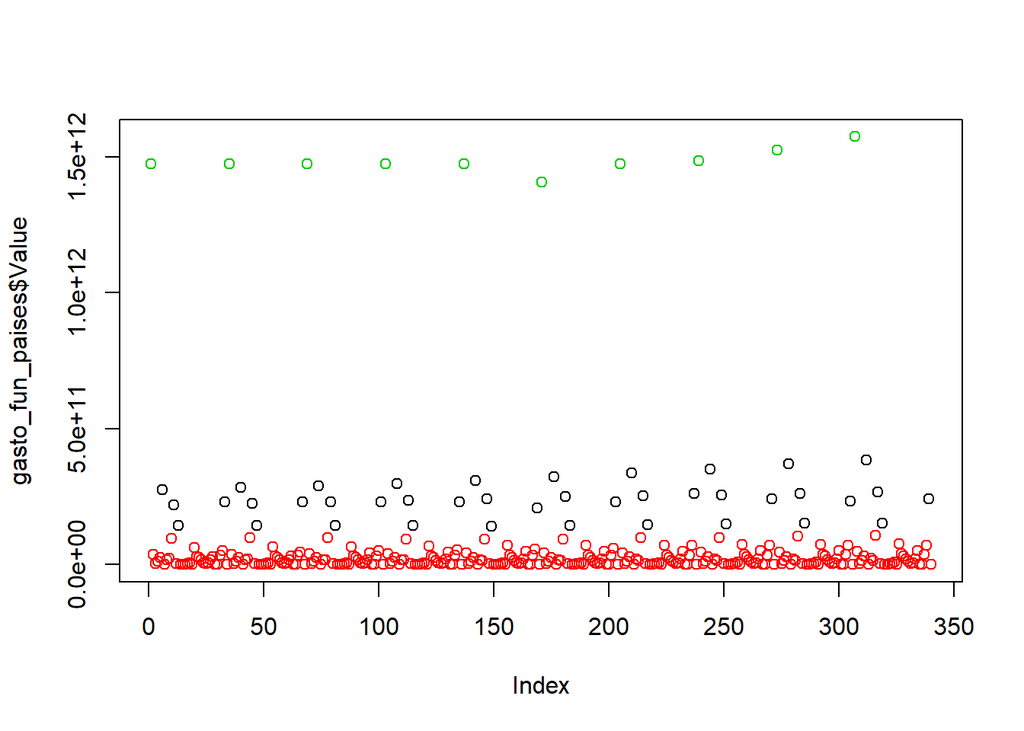

```r
#Representamos los grupos
plot(gasto_fun_paises$Value, col=kmeans_res$cluster)
```